# Global Wild Fish Catch Analysis

Anastasia Kunz

3/2/2021

This analysis utilizes nonlinear least squares to analyze the Earth Policy Institute’s 1950 - 2012 wild fish catch data from the U.N. Food and Agriculture Organization.

```r
fish_catch <- read_csv(here("data", "fish_catch.csv"), skip = 4) %>%
  select(X1, X2) %>%
  rename(year = X1,
         wild_catch = X2) %>%
  head(-4) %>%
  mutate(year = as.numeric(year))
```

### Data Exploration: Wild Fish Catch Time Series & Parameter Estimation

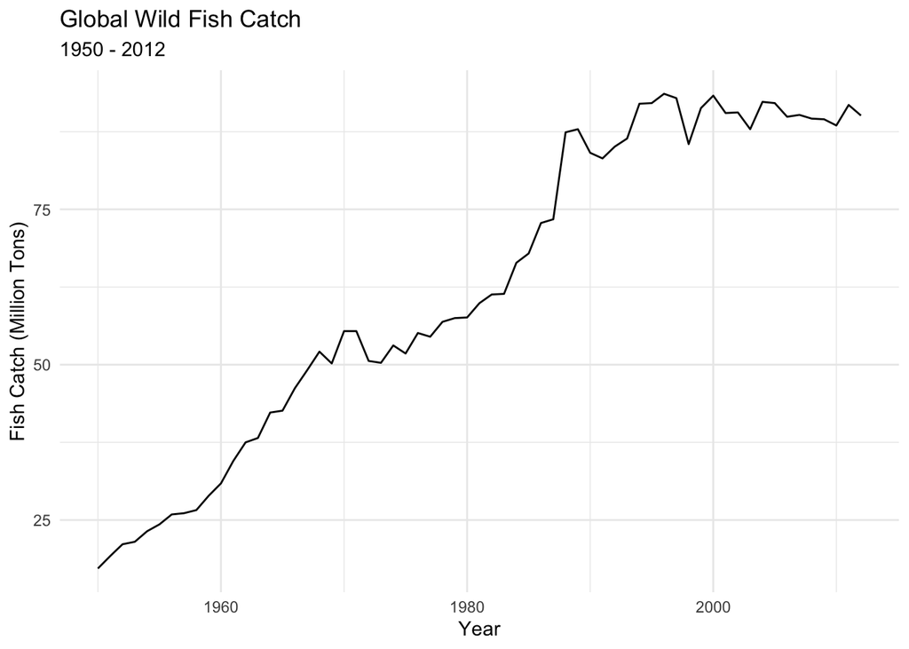

```r
# make time series of fish catch
ggplot(fish_catch, aes(x = year, y = wild_catch))+
  geom_line()+
  theme_minimal()+
  labs(
    x = "Year",
    y = "Fish Catch (Million Tons)",
    title = "Global Wild Fish Catch",
    subtitle = "1950 - 2012"
  )
```

Therefore, we can use $P(t)=\frac{K}{1+Ae^{-kt}}$ as our equation for wild fish catch through time and estimate parameters based off of the graph above.

**K Estimate**

Wild fish catch levels off around 1990, at about 90 to 95 million tons of wild fish catch per year. *So the estimate for K will be 95 million tons.*

**A Estimate**

We can estimate *k* by looking at the log of wild fish catch pre 1990 (shown below) to find the growth rate. *Here we estimate k to be 0.035623.*

[figure not shown]

```r
 # look at data to get a sense of how to estimate k
ggplot(data = fish_catch, aes(x = year, y = log(wild_catch))) +
  geom_point() +
  theme_minimal()+
  labs(
    x = "Log of Wild Fish Catch",
    y = "Year",
    title = "Log Transformed Wild Fish Catch by Year"
  )
```

```r
fish_exp <- fish_catch %>%
  filter(year < 1990) %>%
  mutate(ln_fish = log(wild_catch))

lm_fish <- lm(ln_fish ~ year, data = fish_exp)
```

```r
#update to year starting at 0 instead of 1950

fish_catch_nls <- fish_catch %>%
  mutate(year = (year - 1950))

fish_nls <- nls(wild_catch ~ K/(1 + A*exp(-r*year)),
              data = fish_catch_nls,
              start = list(K = 95, A = 8.5, r = 0.035623),
              trace = TRUE
              )

#summary(fish_nls)

fish_output <- broom::tidy(fish_nls)

A_estimate <- fish_output$estimate[2]
```

### Nonlinear Least Squares Model Outputs and Prediction

Using nonlinear least squares, the graph and table below shows the model outputs and visualization of the nonlinear least squares prediction.

#### Table of Results

```r
fish_output %>%
  gt() %>%
  tab_header(
    title = "Nonlinear Least Squares Model Outputs"
  ) %>%
  fmt_number(
    columns = vars(estimate, std.error, statistic),
    decimals = 2
  ) %>%
  fmt_scientific(
    columns = vars(p.value),
    decimals = 2
  ) %>%
  tab_options(table.width = pct(70)) %>%
  cols_label(
    term = "Term",
    estimate = "Estimate",
    std.error = "Standard Error",
    statistic = "Statistic",
    p.value = "P-Value"
  )
```

Nonlinear Least Squares Model Outputs

| Term | Estimate | Standard Error | Statistic | P-Value |
| --- | --- | --- | --- | --- |
| K | 100.28 | 2.73 | 36.68 | 8.57 × 10<sup>−43</sup> |
| A | 4.32 | 0.29 | 14.73 | 1.34 × 10<sup>−21</sup> |
| r | 0.07 | 0.00 | 15.04 | 5.14 × 10<sup>−22</sup> |

#### Visualization of Prediction and Original Data

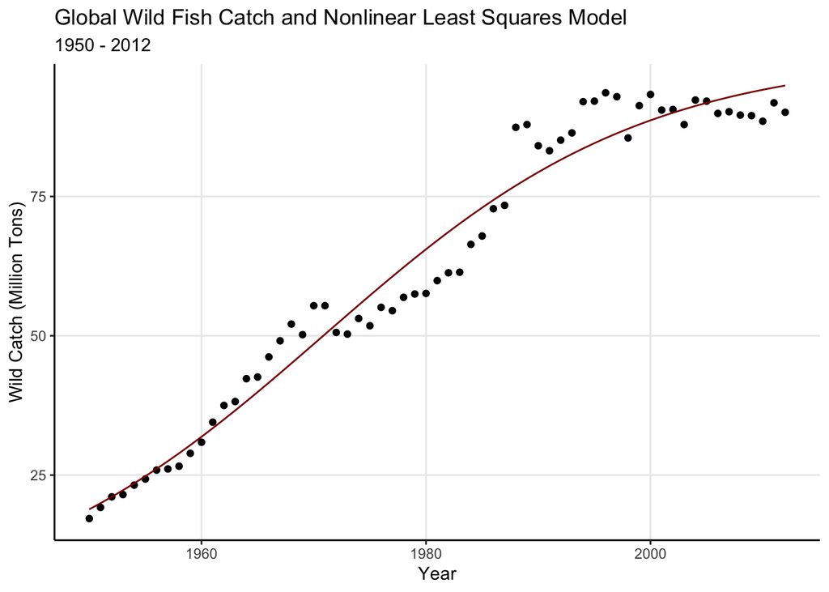

```r
fish_predict <- predict(fish_nls)

# combine data frames into one to plot
fish_catch_complete <- data.frame(fish_catch, fish_predict)

ggplot(data = fish_catch_complete, aes(x = year, y = wild_catch)) +
  geom_point() +
  geom_line(aes(x = year, y = fish_predict), color  = "darkred") +
  theme_classic()+
  labs(
    x = "Year",
    y = "Wild Catch (Million Tons)",
    title = "Global Wild Fish Catch and Nonlinear Least Squares Model",
    subtitle = "1950 - 2012"
  )+
  theme(panel.grid.major = element_line())
```

### Data Citation

Global wild fish catch and aquaculture production, compiled by Earth Policy Institute with 1950-2010 from U.N. Food and Agriculture Organization (FAO), Global Capture Production and Global Aquaculture Production, electronic databases, at www.fao.org/fishery/topic/16140/en.